# Introduction à la Géostatistique en R

Géostatistique pour l’Agronomie

2025-06-17

```r
knitr::opts_chunk$set(echo = TRUE, warning = FALSE, message = FALSE)

# Packages nécessaires
library(gstat)
library(automap)
library(fields)
library(sf)
```

```r
library(sp)
library(shiny)
library(plotly)
library(DT)
library(leaflet)
library(RColorBrewer)
library(akima)
library(dplyr)
```

# 1 Introduction à la Géostatistique

[Lien book](https://shop.elsevier.com/books/computational-methods-for-time-series-analyses-in-earth-sciences/gumiere/978-0-443-33631-7)

## 1.1 Objectifs du cours

- Comprendre les concepts fondamentaux de la géostatistique
- Apprendre à analyser la variabilité spatiale
- Maîtriser les techniques d’interpolation : Krigeage, IDW, TPS
- Implémenter ces méthodes en R

## 1.2 Théorie de base

### 1.2.1 Définition

La géostatistique est une branche de la statistique qui traite des données spatiales. Elle permet d’analyser et de prédire des phénomènes qui varient dans l’espace.

### 1.2.2 Concepts clés

**Variable régionalisée** : Une fonction $Z(x)$ qui associe à chaque point $x$ de l’espace une valeur.

**Hypothèse de stationnarité** :

- Stationnarité stricte : $Z(x)$ et $Z(x+h)$ ont la même distribution
- Stationnarité intrinsèque : $E[Z(x+h) - Z(x)] = 0$ et $Var[Z(x+h) - Z(x)] = 2\gamma(h)$

**Variable régionalisée**

Imaginez que vous mesuriez, par exemple, la teneur en argile ou le pH du sol en de nombreux points d’un champ. On note cela sous la forme d’une fonction :

$Z(x)$

où :

- $x$ représente un point géographique (coordonnées dans le champ),
- $Z(x)$ est la valeur du caractère (pH, argile, humidité…) mesurée en ce point.

Autrement dit, une variable régionalisée est tout simplement une variable qui varie dans l’espace et que l’on connaît partiellement à certains endroits.

**Hypothèse de stationnarité**

Pour modéliser ou interpoler ces valeurs spatiales (par exemple via la krigeage), on fait l’hypothèse de stationnarité, c’est-à-dire qu’on suppose que les statistiques (moyenne, variance…) de Z ne changent pas, ou changent de manière contrôlée, lorsque l’on se déplace dans le champ.

**Stationnarité stricte** « Pour tous les points x et pour quelque vecteur de déplacement h, les deux valeurs Z(x) et Z(x + h) ont la même distribution statistique. »

En pratique, cela revient à dire que, n’importe où dans votre champ, la moyenne et la forme globale de la distribution de votre variable (pH, argile…) sont les mêmes.

**Stationnarité intrinsèque** C’est une version plus légère :

- Espérance des différences nulle $E\bigl[\,Z(x+h) - Z(x)\bigr] = 0$ Autrement dit, en moyenne, on ne s’attend pas à voir un décalage systématique entre deux points séparés de h.
- Variance des différences liée au semi-variogramme $\mathrm{Var}\bigl[\,Z(x+h) - Z(x)\bigr] \;=\; 2\,\gamma(h)$ où $\gamma(h)$ est le semi-variogramme, qui rapporte comment la variabilité entre deux mesures augmente lorsque la distance h s’accroît.

# 2 Préparation des données

[Lien pour les données](https://github.com/sgumiere/CMTSAES)

```r
tb = read.table('data_jacques.txt', header = T)
#summary(tb)
names(tb)[names(tb) == "Z"] <- "k_sat"

# Statistiques descriptives
summary(tb)
```

```
##        X               Y             k_sat
##  Min.   :    0   Min.   :    0   Min.   : 0.230
##  1st Qu.:10000   1st Qu.: 8000   1st Qu.: 1.305
##  Median :14000   Median :10500   Median : 2.160
##  Mean   :13211   Mean   :10452   Mean   : 2.721
##  3rd Qu.:18000   3rd Qu.:13250   3rd Qu.: 3.500
##  Max.   :21000   Max.   :17500   Max.   :14.020
```

## 2.1 Exploration des données

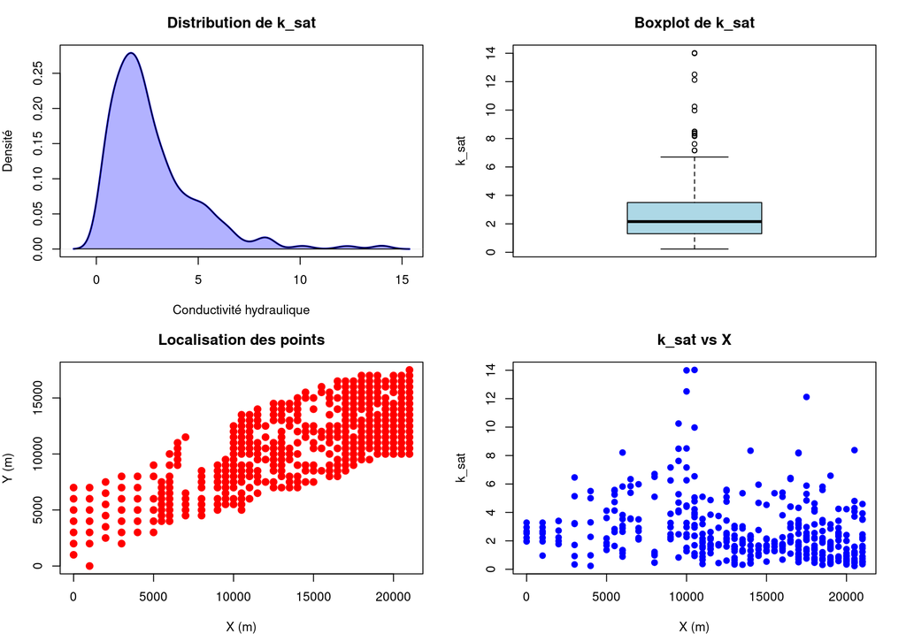

Exploration des données spatiales

```r
par(mfrow=c(2,2), mar=c(4,4,3,2))

# Distribution des données
plot(density(tb$k_sat), main = "Distribution de k_sat",
     xlab = "Conductivité hydraulique", ylab = "Densité",
     col = "blue", lwd = 2)
polygon(density(tb$k_sat), col = rgb(0,0,1,0.3))

# Boxplot
boxplot(tb$k_sat, col='lightblue', main = "Boxplot de k_sat",
        ylab = "k_sat")

# Nuage de points spatial
plot(tb$X, tb$Y, pch = 19, col = "red",
     main = "Localisation des points",
     xlab = "X (m)", ylab = "Y (m)", cex = 1.2)

# Relation spatiale
plot(tb$X, tb$k_sat, pch = 19, col = "blue",
     main = "k_sat vs X", xlab = "X (m)", ylab = "k_sat")
```

## 2.2 Transformation en objet spatial

```r
# Transformation en SpatialPointsDataFrame
tb.geo <- tb
coordinates(tb.geo) <- ~X+Y
class(tb.geo)
```

```
## [1] "SpatialPointsDataFrame"
## attr(,"package")
## [1] "sp"
```

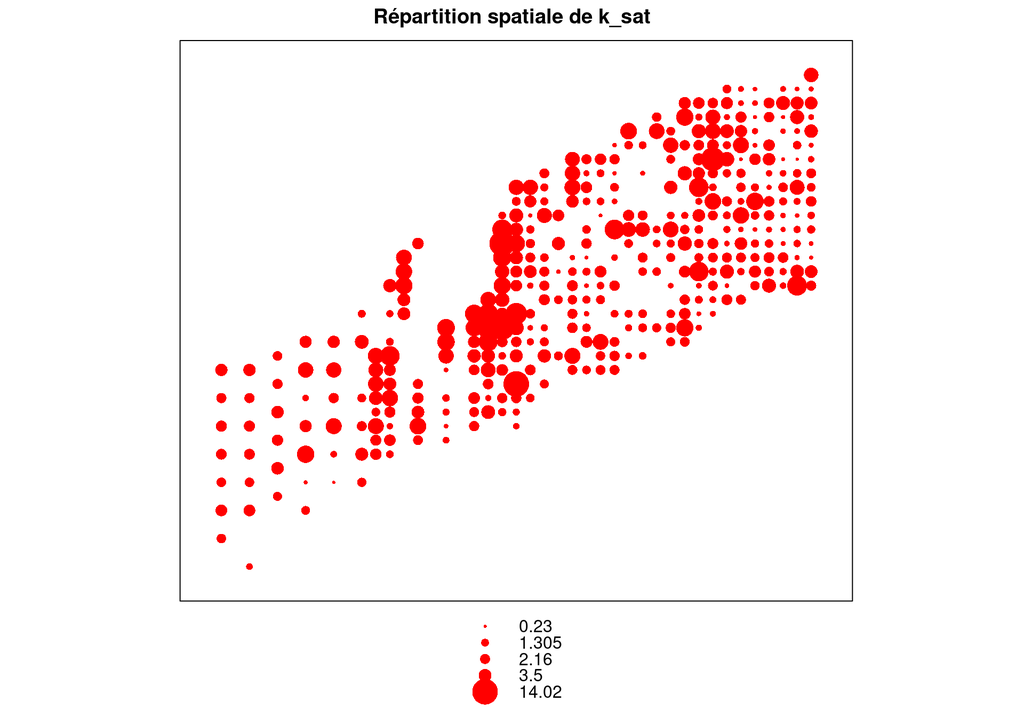

Visualisation spatiale des données

```r
# Visualisation spatiale
bubble(tb.geo, "k_sat", main = "Répartition spatiale de k_sat",
       col = c("blue", "red"), key.space = "bottom")
```

# 3 Analyse du variogramme

## 3.1 Théorie du variogramme

Le **variogramme expérimental** est défini par :

$$\gamma(h) = \frac{1}{2N(h)}
\sum_{i=1}^{N(h)} [Z(x_i) - Z(x_i + h)]^2 \quad \text{(1)}$$

où :

- $h$ est la distance de séparation (lag)
- $N(h)$ est le nombre de paires de points séparés par la distance $h$

## 3.2 Calcul du variogramme expérimental

```r
# Calcul du variogramme expérimental
vgm_exp <- variogram(k_sat~1, tb.geo)

# Affichage sous forme de tableau
vgm_exp
```

| np | dist | gamma | dir.hor | dir.ver | id |
| --- | --- | --- | --- | --- | --- |
| 494 | 500.0000 | 3.629349 | 0 | 0 | var1 |
| 1858 | 982.2538 | 4.019571 | 0 | 0 | var1 |
| 2387 | 1606.6924 | 4.218829 | 0 | 0 | var1 |
| 2266 | 2116.8264 | 4.076688 | 0 | 0 | var1 |
| 3692 | 2692.9524 | 4.373564 | 0 | 0 | var1 |
| 4885 | 3375.5676 | 4.808450 | 0 | 0 | var1 |
| 3250 | 4002.6209 | 4.681135 | 0 | 0 | var1 |
| 4005 | 4524.1849 | 4.697378 | 0 | 0 | var1 |
| 4179 | 5143.2853 | 4.296305 | 0 | 0 | var1 |
| 4089 | 5774.4581 | 4.642576 | 0 | 0 | var1 |

[output cut: 5 more lines]

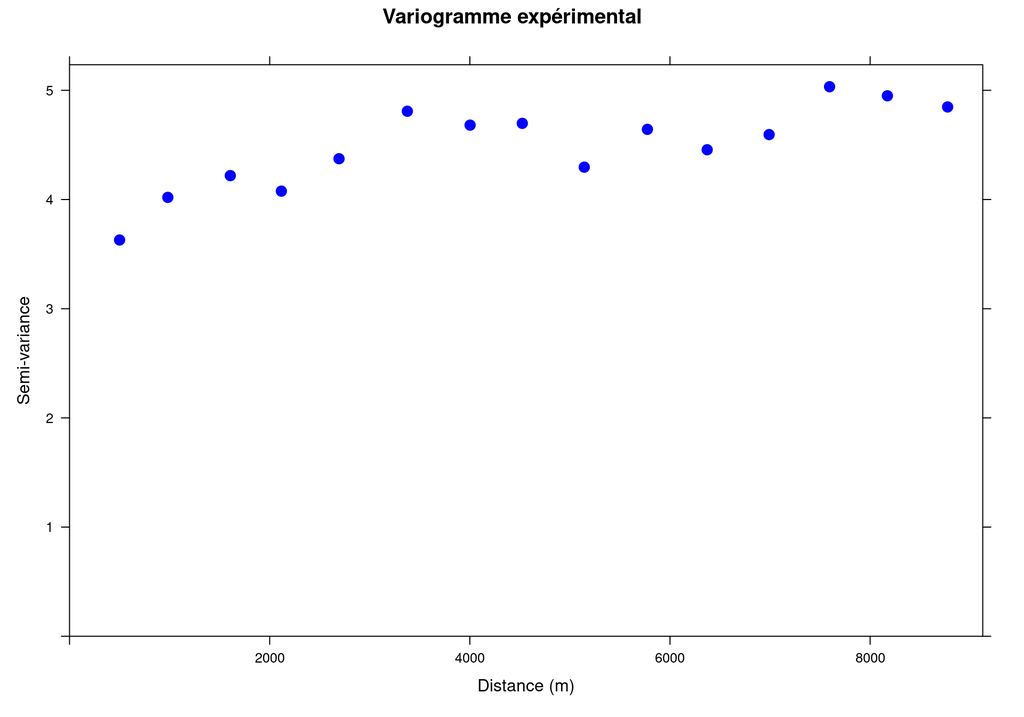

Variogramme expérimental

```r
# Visualisation
plot(vgm_exp, main = "Variogramme expérimental",
     xlab = "Distance (m)", ylab = "Semi-variance",
     pch = 19, col = "blue", cex = 1.2)
```

## 3.3 Modèles théoriques de variogramme

Les modèles les plus courants sont :

### 3.3.1 Modèle sphérique

$$\gamma(h) = C_0 + C_1 \left[
\frac{3h}{2a} - \frac{h^3}{2a^3} \right] \text{ pour } h \leq a \quad
\text{(2a)}$$
$$\gamma(h) = C_0 + C_1
\text{ pour } h > a \quad \text{(2b)}$$

### 3.3.2 Modèle exponentiel

$$\gamma(h) = C_0 + C_1 \left[ 1 -
\exp\left(-\frac{h}{a}\right) \right] \quad \text{(3)}$$

### 3.3.3 Modèle gaussien

$$\gamma(h) = C_0 + C_1 \left[ 1 -
\exp\left(-\frac{h^2}{a^2}\right) \right] \quad \text{(4)}$$

### 3.3.4 Modèle Stein (Matérn)

$$\gamma(h) = C_0 + C_1 \left[ 1 -
\frac{2^{1-\nu}}{\Gamma(\nu)} \left(\frac{h}{a}\right)^\nu
K_\nu\left(\frac{h}{a}\right) \right] \quad \text{(5)}$$

où :

- $C_0$ : effet de pépite (nugget effect)
- $C_1$ : contribution (sill - nugget)
- $a$ : portée (range)
- $\nu$ : paramètre de lissage (pour le modèle Stein)
- $K_\nu$ : fonction de Bessel modifiée de deuxième espèce

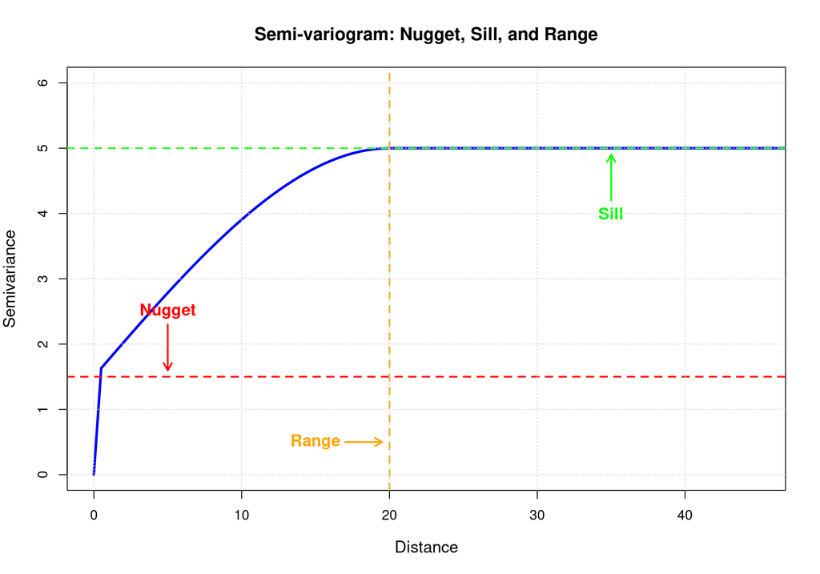

# 4 Ajustement du variogramme

## 4.1 Ajustement automatique du variogramme

```r
# Ajustement automatique avec des valeurs initiales ajustées
vario.fit <- fit.variogram(vgm_exp,
                          model = vgm(2, "Sph", 2000, 3))

# Affichage des paramètres
vario.fit
```

|  | model | psill | range | kappa | ang1 | ang2 | ang3 | anis1 | anis2 |
| --- | --- | --- | --- | --- | --- | --- | --- | --- | --- |
| 1 | Nug | 3.483962 | 0.000 | 0.0 | 0 | 0 | 0 | 1 | 1 |
| 2 | Sph | 1.164029 | 3949.853 | 0.5 | 0 | 0 | 0 | 1 | 1 |

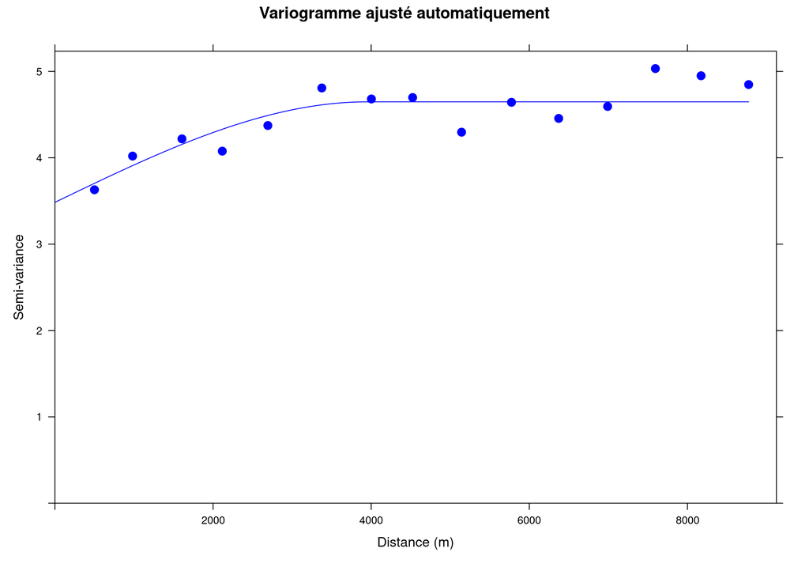

Variogramme ajusté automatiquement

```r
# Visualisation de l'ajustement
plot(vgm_exp, vario.fit,
     main = "Variogramme ajusté automatiquement",
     xlab = "Distance (m)", ylab = "Semi-variance",
     pch = 19, col = "blue", cex = 1.2)
```

```r
# Calcul du RMSE
obs_gamma <- vgm_exp$gamma
pred_gamma <- variogramLine(vario.fit, dist_vector = vgm_exp$dist)$gamma
rmse <- sqrt(mean((obs_gamma - pred_gamma)^2))
cat("RMSE de l'ajustement:", round(rmse, 4), "\n")
```

```
## RMSE de l'ajustement: 0.1973
```

## 4.2 Ajustement manuel avec différents modèles

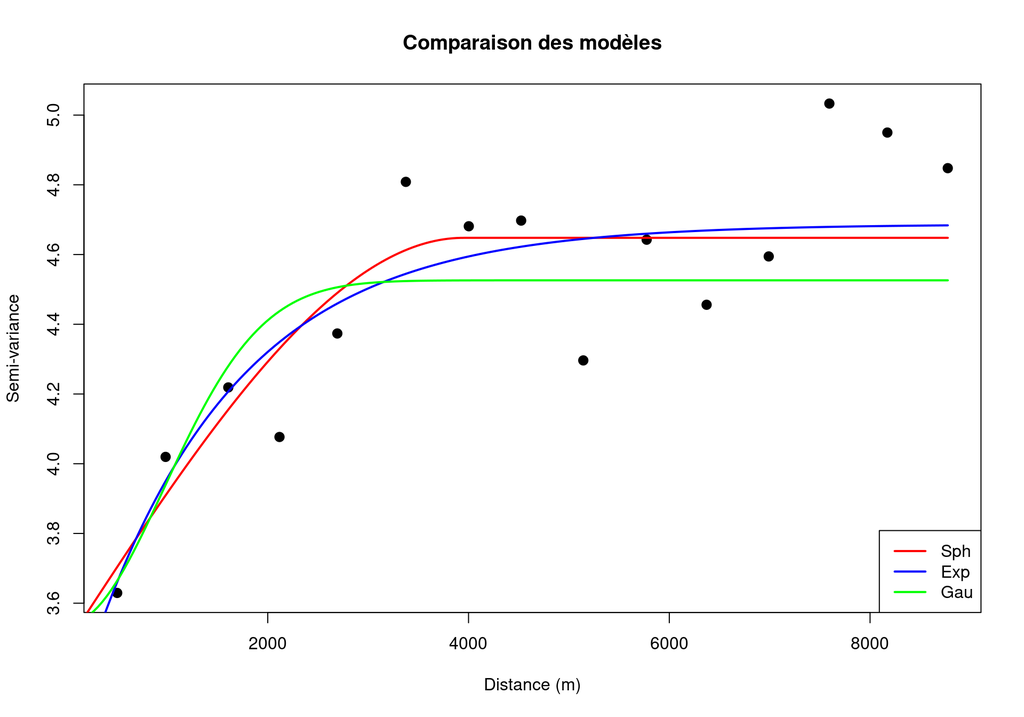

Comparaison des modèles de variogramme

```r
# Test de différents modèles
models <- c("Sph", "Exp", "Gau")
#par(mfrow = c(2, 2))

# Valeurs initiales basées sur le variogramme expérimental
nugget_init <- min(vgm_exp$gamma) * 0.1
sill_init <- max(vgm_exp$gamma)
range_init <- max(vgm_exp$dist) / 3

# Ajustement de chaque modèle
fitted_models <- list()
for(model in models) {
  vgm_initial <- vgm(psill = sill_init - nugget_init,
                     model = model,
                     range = range_init,
                     nugget = nugget_init)

  # Ajustement automatique pour chaque modèle
  fitted_models[[model]] <- fit.variogram(vgm_exp, vgm_initial)

  # Graphique individuel pour chaque modèle
  plot(vgm_exp, fitted_models[[model]],
       main = paste("Modèle", model),
       xlab = "Distance (m)", ylab = "Semi-variance")
}

# Comparaison visuelle globale - utilisation du plot standard
plot(vgm_exp$dist, vgm_exp$gamma,
     main = "Comparaison des modèles",
     xlab = "Distance (m)", ylab = "Semi-variance",
     pch = 19, col = "black", cex = 1.2)

colors <- c("red", "blue", "green")
for(i in 1:length(models)) {
  # Utilisation de variogramLine pour tracer les modèles ajustés
  vgm_line <- variogramLine(fitted_models[[models[i]]], max(vgm_exp$dist))
  lines(vgm_line$dist, vgm_line$gamma, col = colors[i], lwd = 2)
}
legend("bottomright", legend = models, col = colors, lwd = 2)
```

```r
# Tableau de comparaison des paramètres
comparison_params <- data.frame(
  Modèle = models,
  Nugget = sapply(fitted_models, function(x) round(x$psill[1], 3)),
  Sill = sapply(fitted_models, function(x) round(sum(x$psill), 3)),
  Range = sapply(fitted_models, function(x) round(x$range[length(x$range)], 1))
)

comparison_params
```

[output not shown]

# 5 Krigeage ordinaire

## 5.1 Théorie du krigeage

Le krigeage est un estimateur linéaire non biaisé de variance minimale (BLUE) :

$$Z^*(x_0) = \sum_{i=1}^n \lambda_i Z(x_i)
\quad \text{(6)}$$

Avec les contraintes :

- Non-biais : $\sum_{i=1}^n \lambda_i = 1$ (7)
- Variance minimale : $\sigma^2_K = \sum_{i=1}^n \lambda_i \gamma(x_i, x_0) + \mu$ (8)

Le système d’équations du krigeage ordinaire :
$$\begin{cases}
\sum_{j=1}^n \lambda_j \gamma(x_i, x_j) + \mu = \gamma(x_i, x_0) \quad
\text{pour } i = 1, ..., n \\
\sum_{j=1}^n \lambda_j = 1
\end{cases} \quad \text{(9)}$$

## 5.2 Implémentation du krigeage

```r
# Création de la grille d'interpolation
x.range <- as.integer(c(min(tb$X), max(tb$X)))
y.range <- as.integer(c(min(tb$Y), max(tb$Y)))

space <- 100

grd <- expand.grid(x = seq(from = x.range[1], to = x.range[2], by = space),
                   y = seq(from = y.range[1], to = y.range[2], by = space))

coordinates(grd) <- ~ x + y
gridded(grd) <- TRUE

# Krigeage
kriged_ks <- krige(k_sat~1, tb.geo, grd, model = vario.fit)
```

```
## [using ordinary kriging]
```

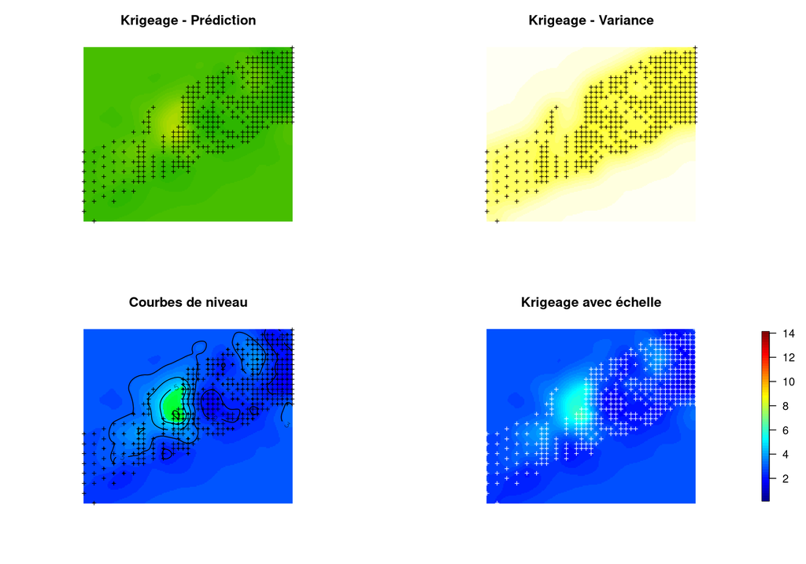

Résultats du krigeage ordinaire

```r
# Visualisation des résultats
par(mfrow = c(2, 2), mar = c(4, 4, 3, 6))

# Prédiction
image(kriged_ks["var1.pred"], main = "Krigeage - Prédiction",
      col = terrain.colors(50))
points(tb$X, tb$Y, pch = '+', cex = 0.8, col = "black")

# Variance de krigeage
image(kriged_ks["var1.var"], main = "Krigeage - Variance",
      col = heat.colors(50))
points(tb$X, tb$Y, pch = '+', cex = 0.8, col = "black")

# Courbes de niveau
image(kriged_ks["var1.pred"], main = "Courbes de niveau",
      col = topo.colors(50))
contour(kriged_ks["var1.pred"], add = TRUE, col = "black")
points(tb$X, tb$Y, pch = '+', cex = 0.8, col = "black")

# Avec échelle de couleur (si fields est disponible)
if("fields" %in% installed.packages()[,"Package"]) {
  image.plot(kriged_ks["var1.pred"],
             main = "Krigeage avec échelle",
             zlim = c(min(tb$k_sat), max(tb$k_sat)))
  points(tb$X, tb$Y, pch = '+', cex = 0.8, col = "white")
} else {
  image(kriged_ks["var1.pred"], main = "Krigeage",
        col = rainbow(50))
  points(tb$X, tb$Y, pch = '+', cex = 0.8, col = "black")
}
```

# 6 Méthode IDW (Inverse Distance Weighting)

## 6.1 Théorie IDW

L’interpolation par pondération inverse de la distance :

$$Z^*(x_0) = \frac{\sum_{i=1}^n
\frac{Z(x_i)}{d_i^p}}{\sum_{i=1}^n \frac{1}{d_i^p}} \quad
\text{(10)}$$

où :

- $d_i$ est la distance entre $x_0$ et $x_i$ : $d_i = \sqrt{(x_0 - x_i)^2 + (y_0 - y_i)^2}$ (11)
- $p$ est l’exposant de puissance (généralement 2)

## 6.2 Implémentation IDW

```r
idw_gstat <- idw(k_sat~1, tb.geo, grd, idp = 2)
```

```
## [inverse distance weighted interpolation]
```

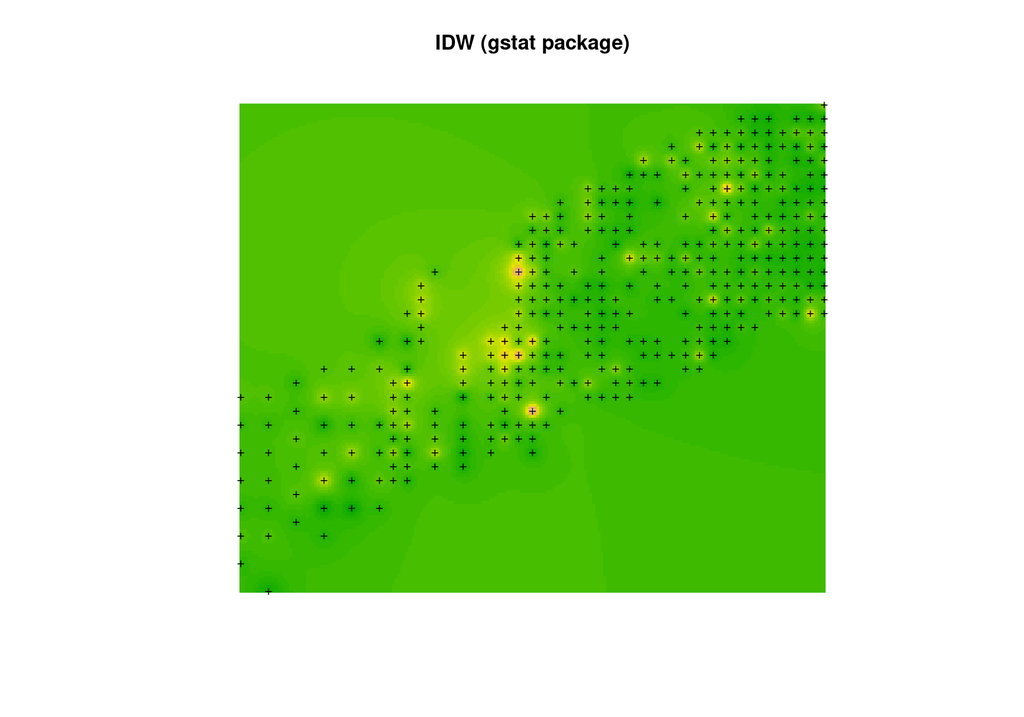

```r
image(idw_gstat["var1.pred"], main = "IDW (gstat package)",
      col = terrain.colors(50))
points(tb$X, tb$Y, pch = '+', cex = 0.8, col = "black")
```

```r
idw1 = gstat(formula = k_sat~1, # intercept only model
              data = tb.geo,
              set = list(idp = 2))


crossval  =  gstat.cv(idw1)


RMSE_idw = sqrt(sum((crossval$residual)^2)/length(crossval$residual))

RMSE_idw
```

[output not shown]

# 7 Méthode TPS (Thin Plate Splines)

## 7.1 Théorie TPS

Les splines de plaque mince minimisent l’énergie de flexion :

$$E = \int \int \left[
\left(\frac{\partial^2 f}{\partial x^2}\right)^2 +
2\left(\frac{\partial^2 f}{\partial x \partial y}\right)^2 +
\left(\frac{\partial^2 f}{\partial y^2}\right)^2 \right] dx dy \quad
\text{(12)}$$

La solution est de la forme :
$$f(x,y) =
a_0 + a_1 x + a_2 y + \sum_{i=1}^n c_i \phi(r_i) \quad
\text{(13)}$$

où $\phi(r) = r^2 \log(r)$ (14) est la fonction radiale de base et $r_i = \sqrt{(x-x_i)^2 + (y-y_i)^2}$ (15)

## 7.2 Implémentation TPS

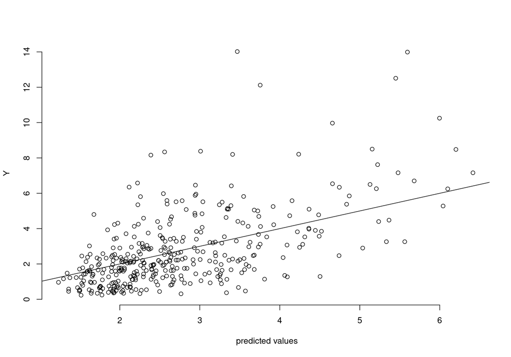

Interpolation par Thin Plate Splines

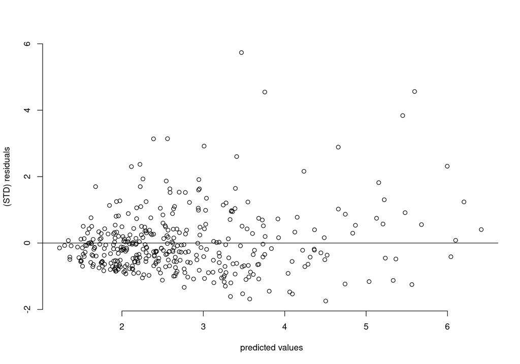

Interpolation par Thin Plate Splines

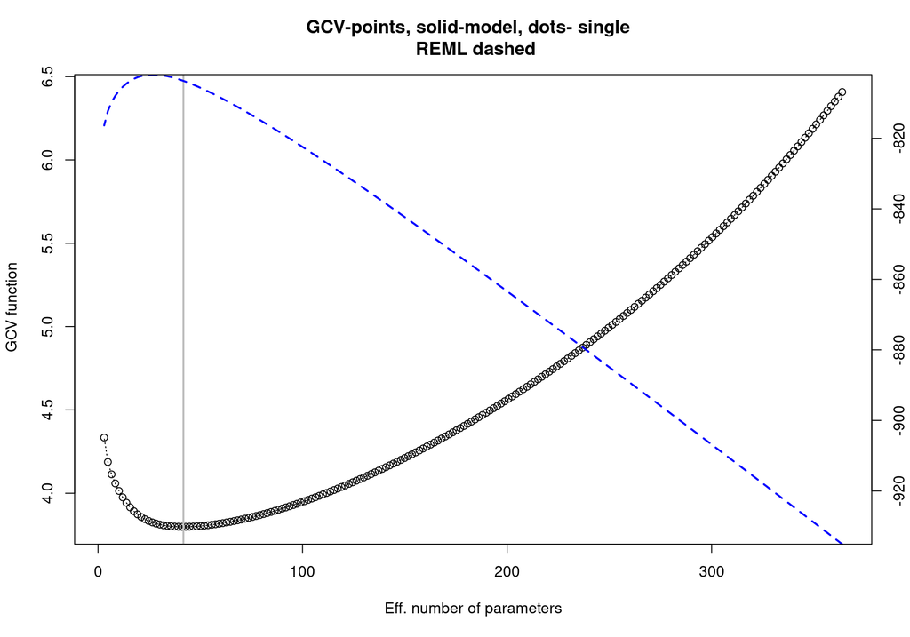

Interpolation par Thin Plate Splines

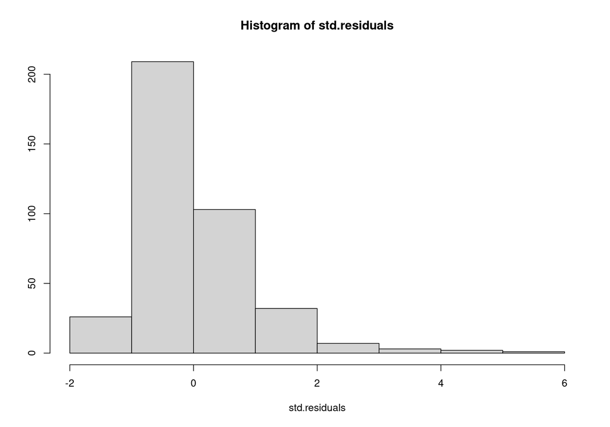

Interpolation par Thin Plate Splines

```r
# Utilisation du package fields pour TPS
library(fields)
tps_fit <- Tps(cbind(tb$X, tb$Y), tb$k_sat)

plot(tps_fit)
```

```r
RMSE_tps = sqrt(sum((tps_fit$residuals)^2)/length(tps_fit$residuals))

RMSE_tps
```

```
## [1] 1.736582
```

## 7.3 Afficher l’image de TPS

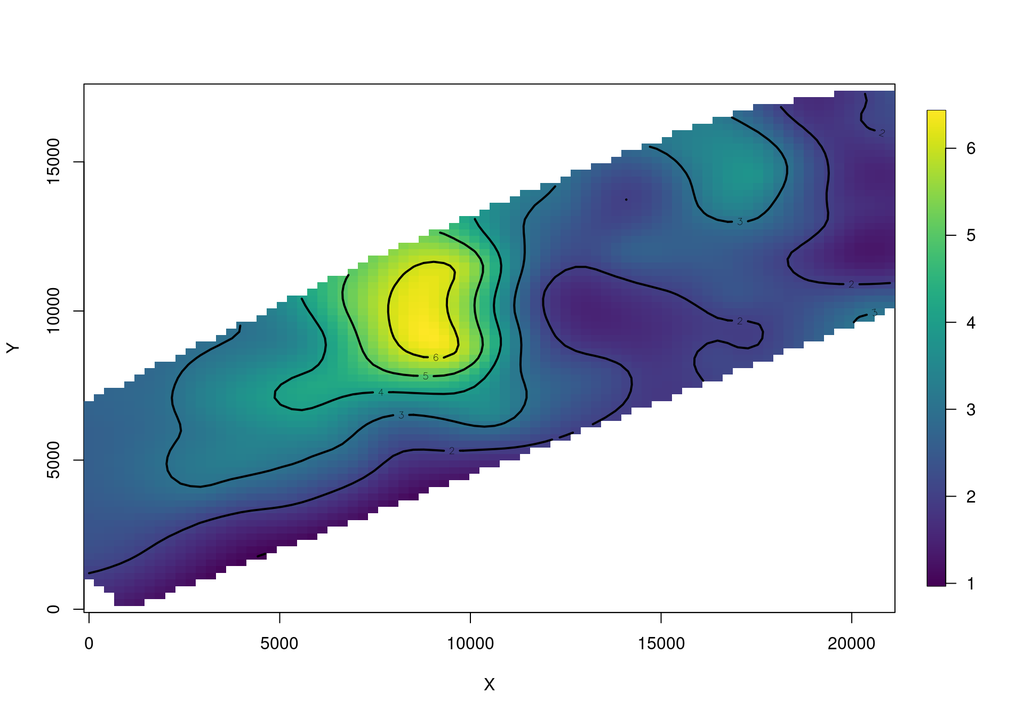

```r
surface(tps_fit)
```

# 8 Résumé et bonnes pratiques

## 8.1 Résumé des méthodes

```r
summary_df <- data.frame(
  Méthode = c("Krigeage", "IDW", "TPS"),
  Avantages = c(
    "Optimal statistiquement, Fournit la variance, Adapté aux données spatiales",
    "Simple à implémenter, Rapide à calculer, Pas d'hypothèses",
    "Lisse et continue, Bon pour les tendances, Robuste"
  ),
  Inconvénients = c(
    "Nécessite un variogramme, Plus complexe",
    "Pas de mesure d'incertitude, Effet de bull's eye",
    "Peut être trop lisse, Sensible aux extrêmes"
  )
)

summary_df
```

| Méthode | Avantages | Inconvénients |
| --- | --- | --- |
| Krigeage | Optimal statistiquement, Fournit la variance, Adapté aux données spatiales | Nécessite un variogramme, Plus complexe |
| IDW | Simple à implémenter, Rapide à calculer, Pas d'hypothèses | Pas de mesure d'incertitude, Effet de bull's eye |
| TPS | Lisse et continue, Bon pour les tendances, Robuste | Peut être trop lisse, Sensible aux extrêmes |

## 8.2 Bonnes pratiques

1. **Exploration des données** : Toujours commencer par une analyse exploratoire
2. **Validation croisée** : Utiliser la validation croisée pour comparer les méthodes
3. **Choix de la méthode** : Dépend de l’objectif et des caractéristiques des données
4. **Incertitude** : Le krigeage est le seul à fournir une estimation de l’incertitude
5. **Transformation** : Considérer la transformation des données si nécessaire

## 8.3 Conclusion

La géostatistique offre un ensemble d’outils puissants pour l’analyse spatiale. Le choix de la méthode dépend :

- De la nature des données
- De l’objectif de l’analyse
- Des ressources computationnelles disponibles
- Du besoin d’estimation de l’incertitude

## 8.4 Exercices pratiques

Essayez avec les données *metaux_champ.csv* les trois méthodes d’interpolation.

## 8.5 Références

- Cressie, N. (1993). *Statistics for Spatial Data*
- Goovaerts, P. (1997). *Geostatistics for Natural Resources Evaluation*
- Bivand, R. S., Pebesma, E., & Gómez-Rubio, V. (2013). *Applied Spatial Data Analysis with R*